# Multiple and Logistic Regression

## Lab Report Template

Your reproducible lab report: Before you get started, please download the R Markdown template for this lab. Remember all of your code and answers go in this document:

```r
download.file("https://jacobfhsmith.github.io/STA101-Fall-2021/sta101_lab9.Rmd", destfile="sta101_lab9.Rmd")
```

- Today, we’ll need `tidyverse`, `readxl`, and the `effects` package.

Your main focus now should be on your group projects, but I want to show you a few last commands in R that are useful for running regressions and then diagnosing if there are any potential problems. We’ve discussed many of these in class, but I wanted to give some examples here.

The data set we are using here includes variables relating to unionization and state economic and political factors in 2018. Much of the data comes from Laura Bucci’s [data set](https://dataverse.unc.edu/dataset.xhtml?persistentId=doi:10.15139/S3/L95PUM), among other sources collect by me. If you want to use this data set for something outside this class, please consult with me about the exact sources for each variable.

# Variables

Let’s load our data first.

```r
UnionData<- read_excel("~/StateUnionEconomicData.xlsx")
```

The variables in this data set are as follows:

- `State`: State Name
- `Abb`: State Abbreviation
- `UnionMember`: Percentage of People in the State in a Union in 2018
- `NonWhite`: Percentage of State Population that was non-white in 2018
- `Manufacturing`: Percentage of State’s Economy that was based in Manufacturing in 2018
- `DispIncome`: Individual Average Disposable Income in 2018
- `MinimumWage`: State Minimum Wage in 2018
- `Poverty`: State Poverty Rate in 2018
- `GDP`: State GDP in 2018
- `MedianAge`: Median Age in 2018
- `HS`: Percentage of People in the State with a High School Degree in 2018
- `College`: Percentage of People in the State with a College Degree in 2018
- `Unemployment`: Unemployment in 2018
- `RTW`: Dummy variable for whether the state has a [right-to-work law](https://en.wikipedia.org/wiki/Right-to-work_law).
- `Trump2016`:Percentage of the Vote Received by Donald Trump in 2016.
- `GOPGOP`: Dummy variable indicating whether the state had a Republican governor in 2018.

# Multiple Regression in R

You want to predict the percentage of people in union in 2018 and think that important factors include whether the state has a “right-to-work” law, how Republican leaning it is (based on the Trump 2016 vote), and the percentage of the economy based in manufacturing. In R, you can do that using the below code.

First, you need to load your data into R.

```r
#Then, you are ready to run the model
UnionizationModel<- lm(UnionData$UnionMember ~ UnionData$RTW + UnionData$Trump2016 + UnionData$Manufacturing)

#Then, look at your model
summary(UnionizationModel)
```

```
##
## Call:
## lm(formula = UnionData$UnionMember ~ UnionData$RTW + UnionData$Trump2016 +
##     UnionData$Manufacturing)
##
## Residuals:
##    Min     1Q Median     3Q    Max
## -7.558 -2.295 -0.490  1.528  7.737
##
## Coefficients:
##                         Estimate Std. Error t value Pr(>|t|)
## (Intercept)             18.77668    3.09452   6.068 2.29e-07 ***
## UnionData$RTW           -5.89918    1.43694  -4.105 0.000164 ***
## UnionData$Trump2016     -0.09585    0.06315  -1.518 0.135925
## UnionData$Manufacturing -3.97515   10.45308  -0.380 0.705484
## ---
## Signif. codes:  0 '***' 0.001 '**' 0.01 '*' 0.05 '.' 0.1 ' ' 1
##
## Residual standard error: 3.508 on 46 degrees of freedom
## Multiple R-squared:  0.5626, Adjusted R-squared:  0.534
## F-statistic: 19.72 on 3 and 46 DF,  p-value: 2.308e-08
```

Also notice that we have both a multiple $R^2$ and an adjusted $R^2$ here and the adjusted $R^2$ is lower. This is because there is a small penalty for each variable that you include in the regression. When they help predict variation in the response variable, it will remain high, but when they do not, the adjusted $R^2$ will decrease and could even theoretically become negative.

# Exercise 1 (15 points)

Please include and run the above code in your RMD file. What do you find after running the model? Please interpret the intercept and *remaining* two coefficients using the one-unit increase framework and then interpret the adjusted R-squared.

# Multicollinearity in R

After running a model, one of the first things you want to do is look for multicollinearity. When your independent variables correlate strongly with one another, it can wreak havoc on your model.

One way to check for multicollinearity is by looking at the [variance inflation factor, or VIF](https://en.wikipedia.org/wiki/Variance_inflation_factor).

To do this, first you should load the car package.

`install.packages("car")`

Then, you are ready to test for multicollinearity.

```r
library(car)
car::vif(UnionizationModel)
```

[output not shown]

# Exercise 2 (5 points)

Include the above code in your RMD file. Do our VIFs here meet the level we discussed in class (> 10, although this is not a set standard) to worry about multicollinearity? Why do you think this is the case?

# Looking for Residuals and Normality

As we did with a simple linear regression last week, it is important to examine the equal variance assumption. Here is code that we can use to examine that condition.

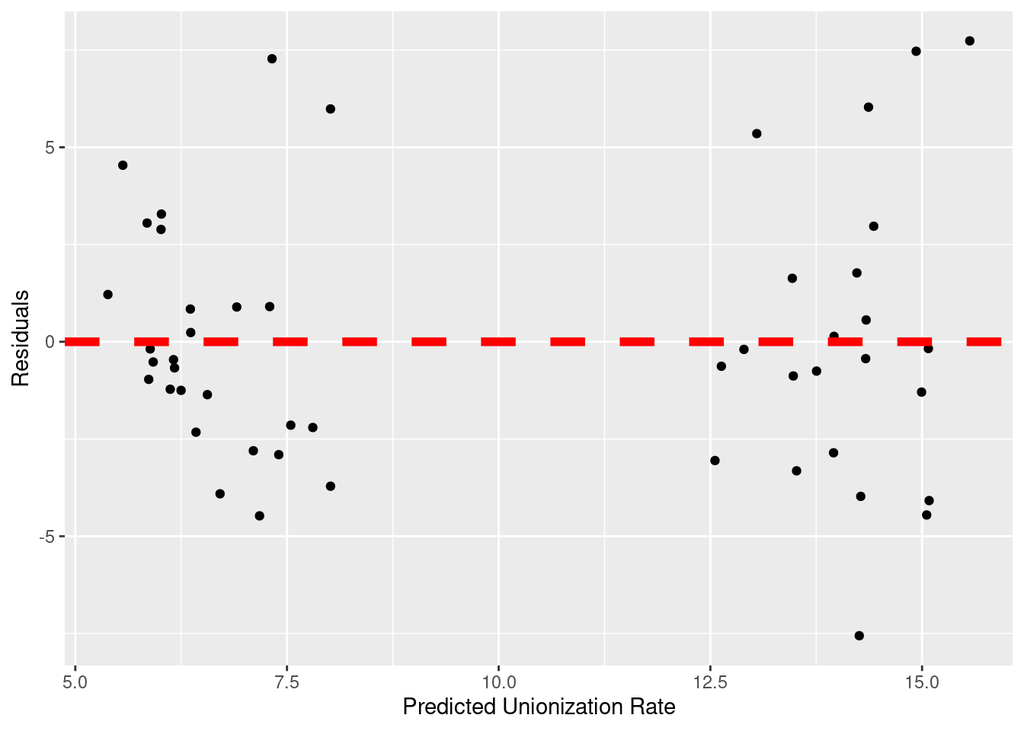

```r
modelaug <- augment(UnionizationModel)

ggplot(modelaug, mapping = aes(x = .fitted, y = .resid)) +
  geom_point() +
  geom_hline(yintercept = 0, lwd = 2, col = "red", lty = 2) +
  labs(x = "Predicted Unionization Rate", y = "Residuals")
```

Here, we observe that the points are pretty evenly spaced above and below zero. (Note: There is a gap in the data- this is likely a result of the effect of the `RTW` variable on our prediction here.)

Now, let’s consider normality using a histogram and a q-q plot.

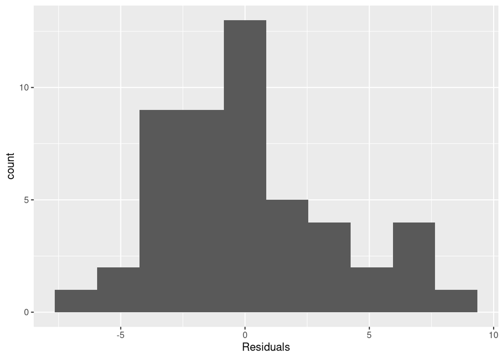

```r
ggplot(modelaug, mapping = aes(x = .resid)) +
  geom_histogram(bins = 10) +
  labs(x = "Residuals")
```

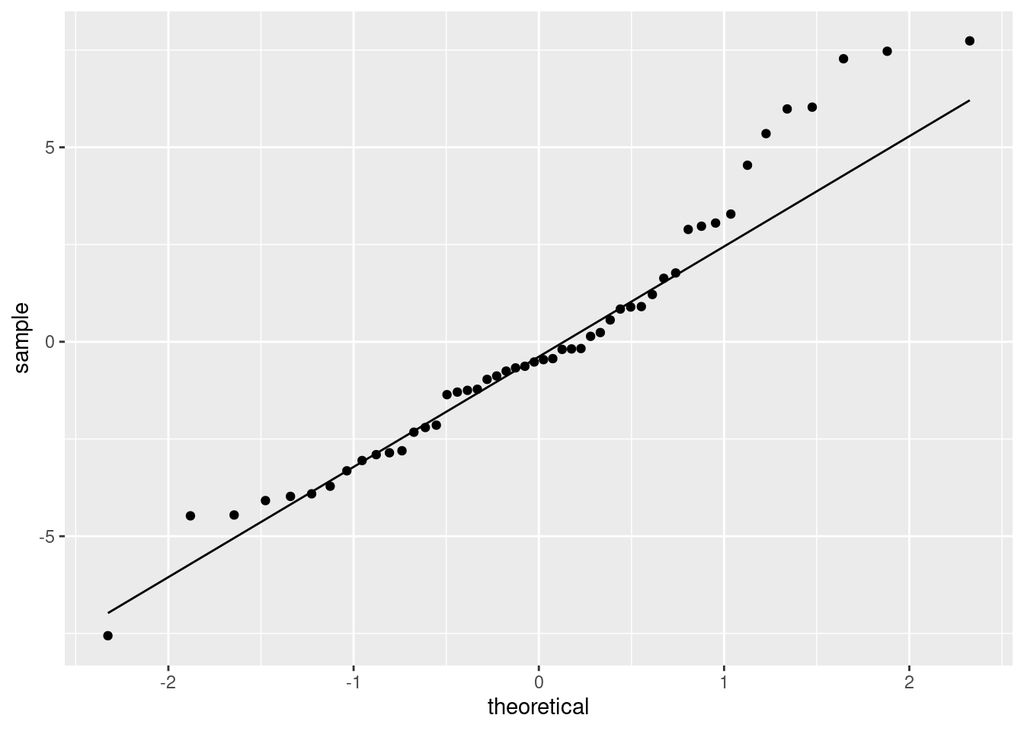

```r
ggplot(modelaug, mapping = aes(sample = .resid)) +
  stat_qq() +
  stat_qq_line()
```

The histogram has some features of a normal distribution (e.g., being bell shaped), but also seems to have a bit of a right skew. Similarly, the q-q plot suggests that the data does not entirely fit the pattern of a normal distribution.

# Exercise 3 (30 points)

On your own, please run a model with a different dependent variable and at least two independent variables. Find the VIF and plot the residuals. Please interpret the output, including intercept, coefficients, and adjusted $R^2$.

# Aside: Logistic Regression in R

In class, we will discuss another type of regression: logistic regression. Logistic regression is a common type of regression used with dichotomous dependent variables (i.e., dummy variables). (If you have a dichotomous dependent variable in your paper, it is okay if you are using an OLS, but it might be a good idea to also fit it as a logit and make a note of whether your results changed.)

We want to predict if a state had a right-to-work law and we think that its political leanings (in terms of Trump vote) and its percent manufacturing were most important at predicting whether it had such a law. We also want to control for education and race.

You can make logistic regression with the [glm](https://www.statmethods.net/advstats/glm.html) function. For a logit, the last part of the code you will write here is family=binomial. You would specify a different command here for other models, but you should copy this if you are running another logit.

```
##
## Call:
## glm(formula = UnionData$RTW ~ UnionData$Trump2016 + UnionData$Manufacturing +
##     UnionData$HS + UnionData$Nonwhite, family = binomial)
##
## Deviance Residuals:
##      Min        1Q    Median        3Q       Max
## -2.25334  -0.29368   0.02424   0.25498   1.75296
##
## Coefficients:
##                         Estimate Std. Error z value Pr(>|z|)
## (Intercept)             40.54226   21.32492   1.901  0.05728 .
## UnionData$Trump2016      0.31315    0.09771   3.205  0.00135 **
## UnionData$Manufacturing 23.29502   12.64042   1.843  0.06534 .
## UnionData$HS            -0.66900    0.27422  -2.440  0.01470 *
## UnionData$Nonwhite       4.99168    7.38589   0.676  0.49914
## ---
## Signif. codes:  0 '***' 0.001 '**' 0.01 '*' 0.05 '.' 0.1 ' ' 1
##
## (Dispersion parameter for binomial family taken to be 1)
##
##     Null deviance: 68.994  on 49  degrees of freedom
## Residual deviance: 25.395  on 45  degrees of freedom
## AIC: 35.395
##
## Number of Fisher Scoring iterations: 7
```

As we will discuss in the last week of class, coefficients from logits cannot be interpreted the same way as for OLS regression models, but the output here still tells you the direction of the relationship and statistical significance.

# Predicted Probability Plots

There are several ways to interpret the output of logistic regression models, but my personal preference are predicted probabilities. You can convert the logit coefficients (which are expressed in log odds) to predicted probabilities of “success” (i.e., the dependent variable is equal to 1) at various levels of the other variables.

Using the [effects](https://data.library.virginia.edu/visualizing-the-effects-of-logistic-regression/) package in R, you can plot predicted probabilities at various levels of the independent variables. Below I plot the predicted probability of a state being right-to-work as you go from the minimum value of an independent variable to the maximum value of that variable. Please note that for each prediction, the other variables are held at their mean value.

(Note: the tick marks on the bottom of each plot represent actual values of that variable. In some cases, you get a prediction for a value for a variable that does not actually exist in the data set. Beware of extrapolation.)

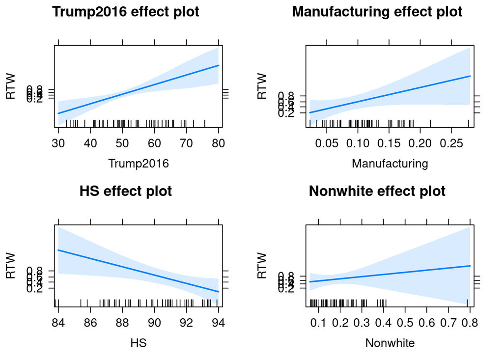

```r
logit1<-glm(RTW~ Trump2016+ Manufacturing+ HS + Nonwhite, data=UnionData ,family=binomial)

plot(allEffects(logit1))
```

Notice here that the y-axis includes some unrealistic values and the labels are kind of scrunched and that there are plots for all four variables here. Using the selection command, you can pick which variable you would like to plot and using ylim, you can change the y-axis scale. Here, I plot the second variable (percent manufacturing) over a narrower scale.

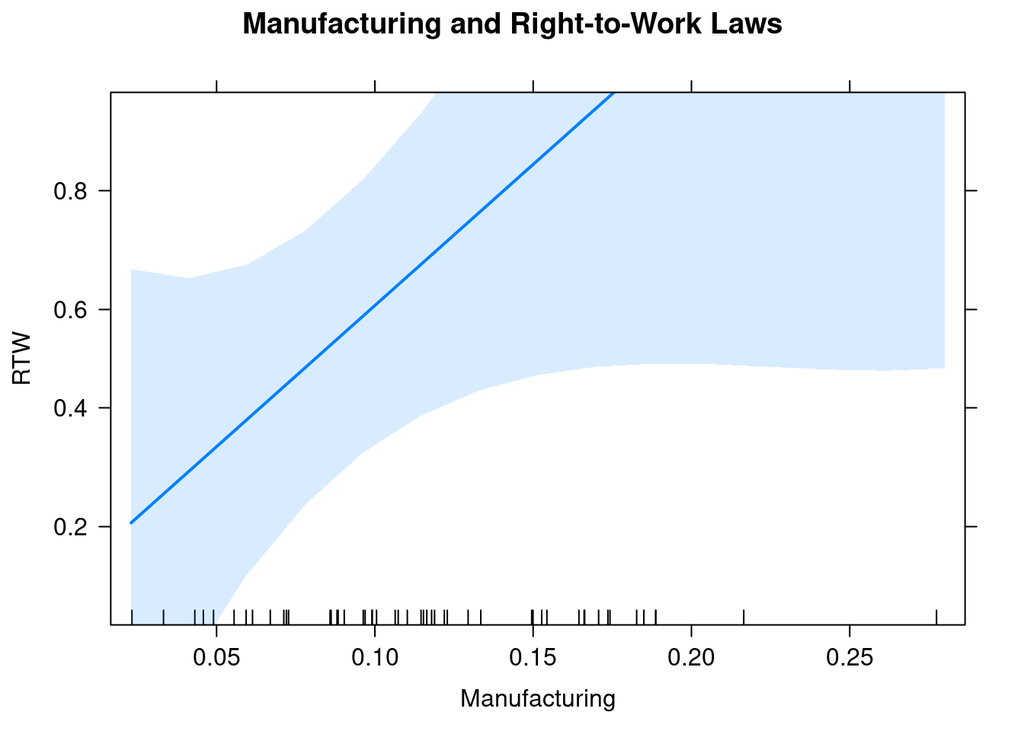

```r
plot(allEffects(logit1), selection=2, ylim = qlogis(c(.1,.9)), main="Manufacturing and Right-to-Work Laws")
```

There are no exercises you need to complete here related to logistic regression, but I wanted to have this as a reference. If you want to try adding a variable and plotting, that would be a place to go if you have time.

# Exercise 4 (50 points)

**Free Response:** What is one thing that you learned this semester about R that you find interesting, important, or relevant or that you might combine with something you learned in another class? Please discuss in a paragraph (five to eight sentences) and up to one graph. (Graph not required)